# Unos podataka u programsko okruženje R i struktura objekata

2024-09-30

## Sadržaj praktikuma

- Uvod u rad u programskom okruženju R i osnovne funkcije, instaliranje programskih paketa
- **Unos podataka u programsko okruženje R, struktura objekata**
- Rad s objektima i podacima te definiranje bioloških varijabli u R-u
- Grafički prikaz bioloških podataka i testiranje razdiobe podataka u R-u
- Primjeri osnovnih statističkih analiza kategoričkih i numeričkih varijabli u biološkim istraživanjima u R-u
- Regresije i korelacije, linearni modeli bioloških podataka – primjeri u R-u
- Primjena parametrijskih statističkih testova bioloških podataka u R-u
- Primjena neparametrijskih statističkih testova bioloških podataka u R-u
- Primjeri multivarijatnih analize bioloških podataka u R-u - linearni modeli, klaster analize i ordinacijske analize

## Sadržaj današnje vježbe

- Kreiranje objekata u R-u - ručni unos
- Varijable, vektori, matrice i podatkovni okviri (*data frame*)
- Provjera tipa podataka
- Provjera strukture objekata
- Učitavanje datoteka u R (tekstualne, CSV i Excel datoteke)
- Pristupanje pojedinačnim stupcima i retcima iz tablica
- Izvoz R objekata u datoteke

## Ručni unos objekata u R-u

### Varijable

```r
### Kreiranje objekata u R-u - ručni unos
# 1. Varijable
x <- 3.14         # numeric - brojčana vrijednost
y <- "DNA"        # character - tekst (mora ići u navodnike)
z <- TRUE         # logical - logička vrijednost (TRUE/FALSE)
```

## Provjera tipa i struktire podataka

```r
# Provjera tipa podataka
class(x) # prikazuje samo tip varijable
```

```
## [1] "numeric"
```

```r
str(x) # struktura: prikazuje tip varijable i što ona sadrži
```

```
##  num 3.14
```

## Provjerite tip podataka varijabli y i z!

```r
# Provjerite tip podataka varijabli y i z!
class(y)
```

```
## [1] "character"
```

```r
class(z)
```

```
## [1] "logical"
```

## Vektori

Vektor je niz elemenata iste vrste (npr. svi brojevi ili svi tekstovi).

```r
# 2. Vektori
geni <- c("BRCA1", "TP53", "MYC")  # tekstualni vektor gena
print(geni)
```

```
## [1] "BRCA1" "TP53"  "MYC"
```

```r
duljine <- c(1863, 1179, 1584)     # numerički vektor duljina gena u parovima baza (bp)
print(duljine)
```

```
## [1] 1863 1179 1584
```

## Matrice

Matrica je 2D struktura podataka iste vrste (redovi x stupci).

```r
# 3. Matrice - skup vektora istog tipa
# Definiranje matrice
matrix_mikrobi <- matrix(c(85, 47, 37, 10, 65, 50, 28, 8),
                         nrow = 4, # postavljanje broja redaka u matrici
                         byrow = TRUE) # definiranje popunjavanja matrice po retcima

# Dodavanje naziva redaka i stupaca
rownames(matrix_mikrobi) <- c("Bakterija1", "Bakterija2", "Gljivica1", "Gljivica2")
colnames(matrix_mikrobi) <- c("CFU_kuhinja", "CFU_kupaonica")
```

```r
print(matrix_mikrobi)
```

```
##            CFU_kuhinja CFU_kupaonica
## Bakterija1          85            47
## Bakterija2          37            10
## Gljivica1           65            50
## Gljivica2           28             8
```

## Podatkovni okvir (*data frame*)

Data frame je struktura podataka koja može sadržavati vektore varijabli raličitih vrsta (brojevi, tekst, logičke vrijednosti).

```r
# 4. Podatkovni okvir (data frame) - skup vektora različitih tipova
df_mikrobi <- data.frame(
  CFU = c(85, 47, 37, 10, 65, 50, 28, 8), # numeručki vektor
  mikrorganizam = c("Bakterija", "Bakterija", "Gljivica", "Gljivica"),  # tekstualni vektor
  lokacija = c("kuhinja", "kupaonica", "kuhinja", "kupaonica") # tekstualni vektor
  )
```

```r
# Uvid u data frame
print(df_mikrobi) # ispis u konzoli
```

```
##   CFU mikrorganizam  lokacija
## 1  85     Bakterija   kuhinja
## 2  47     Bakterija kupaonica
## 3  37      Gljivica   kuhinja
## 4  10      Gljivica kupaonica
## 5  65     Bakterija   kuhinja
## 6  50     Bakterija kupaonica
## 7  28      Gljivica   kuhinja
## 8   8      Gljivica kupaonica
```

```
View(df_mikrobi) # vizualizacija tablice u novom listu
```

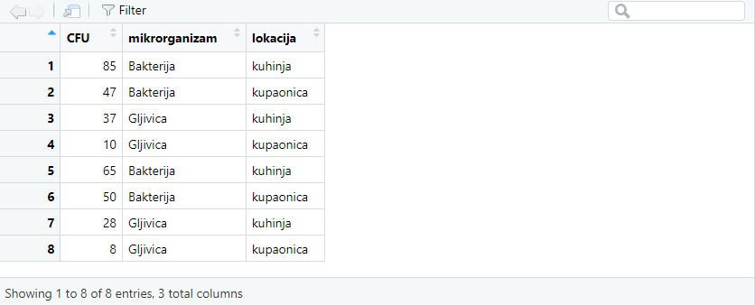

## Učitavanje podataka iz datoteka

```r
### Učitavanje datoteka
# Podsjetimo se naredbi za provjeru i postavljanje radnog direktorija!
getwd()
```

```
## [1] "C:/Users/lucij/Documents/APUBI/02_Unos_podataka"
```

```r
setwd("C:/Users/lucij/Documents/APUBI/02_Unos_podataka") #izmjeniti za vaše računalo!
```

## Učitavanje tekstualnih datoteka

```r
# Učitavanje tekstualnih datoteka
zivotinje <- read.table("zivotinje/zivotinje.txt",
                        header = TRUE)
```

```
View(zivotinje) # ili klik na objekt u environmentu
```

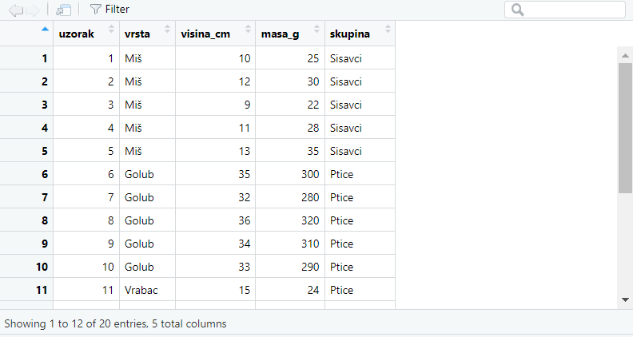

## Učitavanje CSV tablica

```r
# Učitavanje CSV tablica
biljke <- read.csv("biljke/biljke.csv",
                   header = TRUE)
```

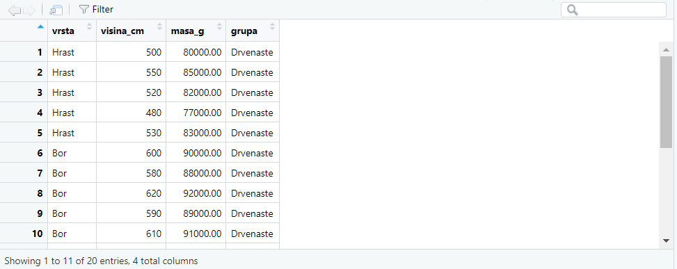

```r
View(biljke) # ili klik na objekt u environmentu
```

## Paket readxl

- Za Excel prvo moramo ucitati paket readxl
- `install.packages(“readxl”)`

```r
library(readxl) # učitavanje paketa
```

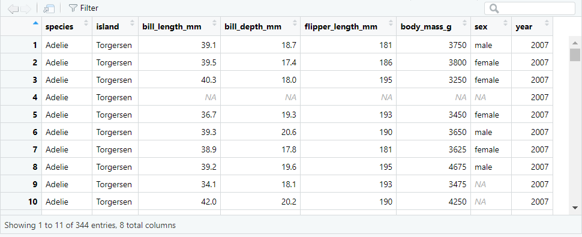

```r
# Učitavanje Excel tablice pingvini
pingvini <- read_excel("pingvini/pingvini.xlsx")
View(pingvini) # ili klik na objekt u environmentu
```

## Pregled i struktura data frame-ova

```r
# Pregled prvih redaka podataka
head(zivotinje)
```

```
##   uzorak vrsta visina_cm masa_g skupina
## 1      1   Miš        10     25 Sisavci
## 2      2   Miš        12     30 Sisavci
## 3      3   Miš         9     22 Sisavci
## 4      4   Miš        11     28 Sisavci
## 5      5   Miš        13     35 Sisavci
## 6      6 Golub        35    300   Ptice
```

```r
# Pregled zadnjih redaka podataka
tail(zivotinje)
```

```
##    uzorak     vrsta visina_cm masa_g skupina
## 15     15    Vrabac        13     21   Ptice
## 16     16 Vjeverica        20    400 Sisavci
## 17     17 Vjeverica        22    420 Sisavci
## 18     18 Vjeverica        21    410 Sisavci
## 19     19 Vjeverica        19    380 Sisavci
## 20     20 Vjeverica        23    430 Sisavci
```

```r
# Tipovi podataka - provjera strukture
str(zivotinje)
```

```
## 'data.frame':    20 obs. of  5 variables:
##  $ uzorak   : int  1 2 3 4 5 6 7 8 9 10 ...
##  $ vrsta    : chr  "Miš" "Miš" "Miš" "Miš" ...
##  $ visina_cm: int  10 12 9 11 13 35 32 36 34 33 ...
##  $ masa_g   : int  25 30 22 28 35 300 280 320 310 290 ...
##  $ skupina  : chr  "Sisavci" "Sisavci" "Sisavci" "Sisavci" ...
```

## Izvlačenje pojedinačnih stupaca data frame-a

```r
# Stupac predstavlja varijable
vrsta_zivotinja <- zivotinje$vrsta
print(vrsta_zivotinja)
```

```
##  [1] "Miš"       "Miš"       "Miš"       "Miš"       "Miš"       "Golub"
##  [7] "Golub"     "Golub"     "Golub"     "Golub"     "Vrabac"    "Vrabac"
## [13] "Vrabac"    "Vrabac"    "Vrabac"    "Vjeverica" "Vjeverica" "Vjeverica"
## [19] "Vjeverica" "Vjeverica"
```

## Izvlačenje pojedinačnih redaka data frame-a

```r
# Redak predstavlja uzorke
zivotinja_1 <- zivotinje[1, ]
print(zivotinja_1)
```

```
##   uzorak vrsta visina_cm masa_g skupina
## 1      1   Miš        10     25 Sisavci
```

## Izvoz R objekata u datoteke

- koristimo naredbu `write.table()`
- nova datoteka će se stvoriti u radnom direktoriju u kojem se trenutno nalazimo

```r
# Izvoz R objekata u datoteke
write.table(df_mikrobi, # definiramo koji objekt želimo eksportati
            file = "mikrobi.csv", # definiramo naziv datoteke
            sep = ",", # definiramo separatore stupaca
            row.names = FALSE) # definiramo da R ne zapiše broj redaka u zasebni stupac
```

## Zadaci

1. Kreirajte 2 varijable, u jednu spremite ime vrste po vašem izboru, a u drugu broj jedinki te vrste.
2. Ispištie tip objekta za novokreirane varijable.
3. Kreirajte 2 vektora, u jednom pohranite tekstove, a u drugom brojeve.
4. Kreirajte data frame s biološkim podacima po vašem izboru, mora sadržavati 2 numeričke i 2 kategoričke varijable.
5. Ispištie strukturu novokreiranog data frame-a.
6. Iz vašeg kreiranog data frame-a izolirajte jedan stupac i spremite ga u novi vektor.

## Rješenje zadatka 1

```r
# 1. Kreirajte 2 varijable, u jednu spremite ime vrste po vašem izboru, a u drugu broj jedinki te vrste.
vrsta <- "glavata zelva"
brojnost <- 26
```

## Rješenje zadatka 2

```r
# 2. Ispištie tip objekta za novokreirane varijable.
class(vrsta)
```

```
## [1] "character"
```

```r
class(brojnost)
```

```
## [1] "numeric"
```

## Rješenje zadatka 3

```r
#3. Kreirajte 2 vektora, u jednom pohranite tekstove, a u drugom brojeve.
vektor_kornjača <- c("glavata želva", "zelena želva", "sedmopruga usminjača")
vekror_jedinki <- c(27, 17, 7)
```

## Rješenje zadatka 4

```r
# 4. Kreirajte data frame s biološkim podacima po vašem izboru,
# mora sadržavati 2 numeričke i 2 kategoričke varijable.
df_kornjače <- data.frame(
  vrsta = c("glavata želva", "zelena želva", "sedmopruga usminjača"),
  brojnost = c(27, 17, 7),
  duljina = c(58, 39, 96),
  lokacija = c("Jadransko more", "Jadransko more", "Tirensko more")
)
```

## Rješenje zadatka 5

```r
# 5. Ispištie strukturu novokreiranog data frame-a.
str(df_kornjače)
```

```
## 'data.frame':    3 obs. of  4 variables:
##  $ vrsta   : chr  "glavata želva" "zelena želva" "sedmopruga usminjača"
##  $ brojnost: num  27 17 7
##  $ duljina : num  58 39 96
##  $ lokacija: chr  "Jadransko more" "Jadransko more" "Tirensko more"
```

## Rješenje zadatka 6

```r
# 6. Iz vašeg kreiranog data frame-a izolirajte jedan stupac i spremite ga u novi vektor.
lokacija_kornjače <- df_kornjače$lokacija
print(lokacija_kornjače)
```

```
## [1] "Jadransko more" "Jadransko more" "Tirensko more"
```